# Part II - 2019 Ford Go Bike Project

## by Asiimwe Victor Emmanuel

## Investigation Overview

> Ford Go bike is San Francisco’s regional bike share network. It exists as a public-private partnership between the Metropolitan Transportation Commission and Motivate. Ford Motor Company is one of the program’s main sponsor partners.

## Dataset Overview

> The dataset has 183412 data rows and 16 data columns, that is, 183412 trips and 16 features(related details). 7 features have the float data type, 2 features have the integer data type, and the other 7 have the integer data type

## Composition of the bike rider type: customer or subscriber

> Subscribers use 90.5% of the total bike trip population, that is, 158386

> Customers only use 9.5% of the total bike trip population, that is, 16566

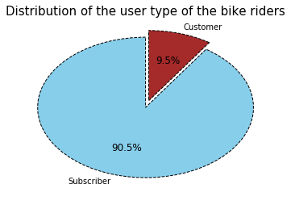

## Gender composition of the users

> the male gender has the highesst number of bike riders turning up for the event

> the male gender is 74.6% of the total population

> the female gender is 23.3% of the total population

> the other gender is only 2.1% of the total population

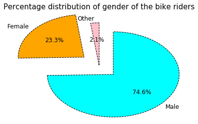

## The relationship between age and the duration in minutes

> there is an indirect proporptionality between the age and duration in minutes variables

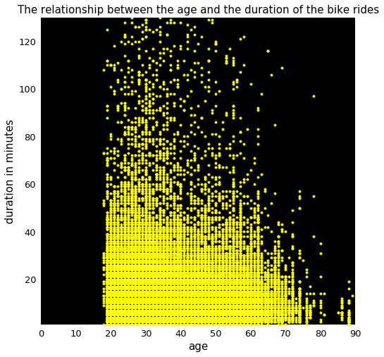